# Algerian Forest Fires

2022-12-13

## Packages Needed

- **install.packages(“caret”)**  
  The caret package contains functions to streamline the model training process for complex regression and classification problems.
- **install.packages(“corrplot”)**  
  The corrplot package provides a visual exploratory tool on correlation matrix that supports automatic variable reordering to help detect hidden patterns among variables.
- **install.packages(“psych”)**  
  A package for personality, psychometric, and psychological research.
- **install.packages(“randomForest”)**  
  The randomForest packages allows us to create random forests.
- **install.packages(“rsample”)**  
  The rsample package makes it easy to create resamples for estimating distributions and assessing model performance.
- **install.packages(“C50”)**  
  We use this package to apply C50 boosting algorithm.

**install.packages(“rpart.plot”)**  
We use this package to plot  
the ROC curve.

- **install.packages(“MASS”)**  
  This package includes many useful functions and data examples, including functions for estimating linear models through generalized least squares (GLS), fitting negative binomial linear models, the robust fitting of linear models, and Kruskal’s non-metric multidimensional scaling.
- **install.packages(‘MLeval’)**  
  This package is used to calculate the roc curve.

## Exploratory Data Analysis

```r
region1Data = read.csv("Algerian_forest_fires_dataset.csv",skip=1, nrows=122)
#Data of the first region, we skip the name of the first region and only add first 122 rows

region2Data = read.csv("Algerian_forest_fires_dataset.csv",skip=126)
#Data of the second region, we skip the first 126 lines which include region 1 and name of region 2

allRegionData = rbind(region1Data,region2Data)
#Data of the whole region, we combine the previous 2 variables
```

The used dataset “Algerian_forest_fires_dataset.csv” contains 244 observations on two regions of Algeria: the Bejaia and Sidi Bel-abbes, located in the northeast and the northwest of the country respectively. There were a couple issues in the csv file that we fixed manually. We deleted the spacing in the titles of the features and fixed line 171, where there were 2 numbers at DC which resulted in “fire” being at FWI. All other changes to the data were done from the code. We added the updated excel sheet.  
It contains 14 features, where Classes(fire or not fire) is our output and the rest of the features are inputs. The description of the dataset is as follows:

[output not shown]

We will be building models and analyzing the data in the regions. Some models were made on regions 1 and 2 alone, but our main focus was on the whole region to generalize. We can see below a summary of the features, in addition to the exact number of rows and columns. As expected, the 244 observations are divided equally across the 2 regions.

```r
summary(region1Data)
```

```
##       day            month          year       Temperature          RH
##  Min.   : 1.00   Min.   :6.0   Min.   :2012   Min.   :22.00   Min.   :45.00
##  1st Qu.: 8.00   1st Qu.:7.0   1st Qu.:2012   1st Qu.:29.00   1st Qu.:60.00
##  Median :16.00   Median :7.5   Median :2012   Median :31.00   Median :68.00
##  Mean   :15.75   Mean   :7.5   Mean   :2012   Mean   :31.18   Mean   :67.98
##  3rd Qu.:23.00   3rd Qu.:8.0   3rd Qu.:2012   3rd Qu.:34.00   3rd Qu.:77.75
##  Max.   :31.00   Max.   :9.0   Max.   :2012   Max.   :37.00   Max.   :89.00
##        Ws          Rain              FFMC            DMC
##  Min.   :11   Min.   : 0.0000   Min.   :28.60   Min.   : 0.700
##  1st Qu.:14   1st Qu.: 0.0000   1st Qu.:65.92   1st Qu.: 3.725
##  Median :16   Median : 0.0000   Median :80.90   Median : 9.450
##  Mean   :16   Mean   : 0.8426   Mean   :74.67   Mean   :12.315
##  3rd Qu.:18   3rd Qu.: 0.5000   3rd Qu.:86.78   3rd Qu.:16.300
##  Max.   :26   Max.   :16.8000   Max.   :90.30   Max.   :54.200
##        DC              ISI              BUI             FWI
##  Min.   :  6.90   Min.   : 0.000   Min.   : 1.10   Min.   : 0.000
##  1st Qu.: 10.05   1st Qu.: 1.125   1st Qu.: 5.10   1st Qu.: 0.500
##  Median : 35.55   Median : 2.650   Median :11.20   Median : 3.000
##  Mean   : 53.16   Mean   : 3.656   Mean   :15.43   Mean   : 5.578
##  3rd Qu.: 79.03   3rd Qu.: 5.600   3rd Qu.:21.68   3rd Qu.: 8.700
##  Max.   :220.40   Max.   :12.500   Max.   :67.40   Max.   :30.200
##    Classes
##  Length:122
##  Class :character
##  Mode  :character
##
##
##
```

```r
dim(region1Data)
```

```
## [1] 122  14
```

```r
summary(region2Data)
```

```
##       day            month          year       Temperature          RH
##  Min.   : 1.00   Min.   :6.0   Min.   :2012   Min.   :24.00   Min.   :21.00
##  1st Qu.: 8.00   1st Qu.:7.0   1st Qu.:2012   1st Qu.:30.00   1st Qu.:43.25
##  Median :16.00   Median :7.5   Median :2012   Median :34.00   Median :56.00
##  Mean   :15.75   Mean   :7.5   Mean   :2012   Mean   :33.16   Mean   :55.90
##  3rd Qu.:23.00   3rd Qu.:8.0   3rd Qu.:2012   3rd Qu.:36.00   3rd Qu.:66.75
##  Max.   :31.00   Max.   :9.0   Max.   :2012   Max.   :42.00   Max.   :90.00
##        Ws             Rain             FFMC            DMC
##  Min.   : 6.00   Min.   :0.0000   Min.   :37.90   Min.   : 0.900
##  1st Qu.:14.00   1st Qu.:0.0000   1st Qu.:77.65   1st Qu.: 7.325
##  Median :15.00   Median :0.0000   Median :84.85   Median :13.150
##  Mean   :15.01   Mean   :0.6787   Mean   :81.10   Mean   :17.032
##  3rd Qu.:16.75   3rd Qu.:0.4750   3rd Qu.:89.28   3rd Qu.:22.900
##  Max.   :29.00   Max.   :8.7000   Max.   :96.00   Max.   :65.900
##        DC              ISI              BUI             FWI
##  Min.   :  7.30   Min.   : 0.100   Min.   : 1.40   Min.   : 0.000
##  1st Qu.: 14.70   1st Qu.: 1.825   1st Qu.: 7.40   1st Qu.: 0.925
##  Median : 31.50   Median : 4.600   Median :13.90   Median : 6.050
##  Mean   : 45.42   Mean   : 5.864   Mean   :17.92   Mean   : 8.520
##  3rd Qu.: 56.98   3rd Qu.: 8.625   3rd Qu.:23.88   3rd Qu.:13.650
##  Max.   :177.30   Max.   :19.000   Max.   :68.00   Max.   :31.100
##    Classes
##  Length:122
##  Class :character
##  Mode  :character
##
##
##
```

```r
dim(region2Data)
```

```
## [1] 122  14
```

```r
summary(allRegionData)
```

```
##       day            month          year       Temperature          RH
##  Min.   : 1.00   Min.   :6.0   Min.   :2012   Min.   :22.00   Min.   :21.00
##  1st Qu.: 8.00   1st Qu.:7.0   1st Qu.:2012   1st Qu.:30.00   1st Qu.:52.00
##  Median :16.00   Median :7.5   Median :2012   Median :32.00   Median :63.00
##  Mean   :15.75   Mean   :7.5   Mean   :2012   Mean   :32.17   Mean   :61.94
##  3rd Qu.:23.00   3rd Qu.:8.0   3rd Qu.:2012   3rd Qu.:35.00   3rd Qu.:73.25
##  Max.   :31.00   Max.   :9.0   Max.   :2012   Max.   :42.00   Max.   :90.00
##        Ws            Rain              FFMC            DMC
##  Min.   : 6.0   Min.   : 0.0000   Min.   :28.60   Min.   : 0.70
##  1st Qu.:14.0   1st Qu.: 0.0000   1st Qu.:72.08   1st Qu.: 5.80
##  Median :15.0   Median : 0.0000   Median :83.50   Median :11.30
##  Mean   :15.5   Mean   : 0.7607   Mean   :77.89   Mean   :14.67
##  3rd Qu.:17.0   3rd Qu.: 0.5000   3rd Qu.:88.30   3rd Qu.:20.75
##  Max.   :29.0   Max.   :16.8000   Max.   :96.00   Max.   :65.90
##        DC              ISI             BUI             FWI
##  Min.   :  6.90   Min.   : 0.00   Min.   : 1.10   Min.   : 0.000
##  1st Qu.: 13.28   1st Qu.: 1.40   1st Qu.: 6.00   1st Qu.: 0.700
##  Median : 33.10   Median : 3.50   Median :12.45   Median : 4.450
##  Mean   : 49.29   Mean   : 4.76   Mean   :16.67   Mean   : 7.049
##  3rd Qu.: 68.15   3rd Qu.: 7.30   3rd Qu.:22.52   3rd Qu.:11.375
##  Max.   :220.40   Max.   :19.00   Max.   :68.00   Max.   :31.100
##    Classes
##  Length:244
##  Class :character
##  Mode  :character
##
##
##
```

```r
dim(allRegionData)
```

```
## [1] 244  14
```

## Dividing the data

```r
library(caret)
#use caret library
df <- as.data.frame(df)

set.seed(55)
#Set seed to get consistent results


region1Train = sample(nrow(region1Data),nrow(region1Data)/2)
region2Train = sample(nrow(region2Data),nrow(region2Data)/2)
allRegionTrain = sample(nrow(allRegionData),nrow(allRegionData)/2)
#assigning the training data randomly

region1Data <- data.frame(region1Data)
region1TrainData <- region1Data[region1Train,]
region1TestData <- region1Data[-region1Train,]

region2Data <- data.frame(region2Data)
region2TrainData <- region2Data[region2Train,]
region2TestData <- region2Data[-region2Train,]

allRegionTrainData <- allRegionData[allRegionTrain,]
allRegionTestData <- allRegionData[-allRegionTrain,]
#using the random numbers to assign the training and test sets
```

## Feature Selection

We will apply feature selection to reduce the features which aren’t significant.

```r
library(psych)
```

```r
library(corrplot)
library(randomForest)
tempRegion1Data = region1Data
tempRegion2Data = region2Data
tempWholeRegionData = allRegionData
#saving the data in temporary variables

tempRegion1Data$Classes <- as.factor(trimws(tempRegion1Data$Classes))
levels(tempRegion1Data$Classes) <- c('fire','not_fire')
tempRegion1Data$Classes <- unclass(factor(tempRegion1Data$Classes))
#trimming the data, changing the classes to fire and not_fire(to avoid spacing issues) and using unclass to change them to numerical data where fire = 1 and not_fire = 2

tempRegion2Data$Classes <- as.factor(trimws(tempRegion2Data$Classes))
levels(tempRegion2Data$Classes) <- c('fire','not_fire')
tempRegion2Data$Classes <- unclass(factor(tempRegion2Data$Classes))

tempWholeRegionData$Classes <- as.factor(trimws(tempWholeRegionData$Classes))
levels(tempWholeRegionData$Classes) <- c('fire','not_fire')
tempWholeRegionData$Classes <- unclass(factor(tempWholeRegionData$Classes))
```

### Region 1

```r
sapply(tempRegion1Data, class)
```

```
##         day       month        year Temperature          RH          Ws
##   "integer"   "integer"   "integer"   "integer"   "integer"   "integer"
##        Rain        FFMC         DMC          DC         ISI         BUI
##   "numeric"   "numeric"   "numeric"   "numeric"   "numeric"   "numeric"
##         FWI     Classes
##   "numeric"   "integer"
```

```r
#some of the feature are of integer type not numerical type

tempRegion1Data$day=as.numeric(tempRegion1Data$day)
tempRegion1Data$month=as.numeric(tempRegion1Data$month)
tempRegion1Data$year=as.numeric(tempRegion1Data$year)
tempRegion1Data$Temperature=as.numeric(tempRegion1Data$Temperature)
tempRegion1Data$RH=as.numeric(tempRegion1Data$RH)
tempRegion1Data$Ws=as.numeric(tempRegion1Data$Ws)
tempRegion1Data$Classes=as.numeric(tempRegion1Data$Classes)
tempRegion1Data = subset(tempRegion1Data, select = -c(year) )
#changing all integer columns to numeric to create the correlation matrix, we also removed year since it is the same in all observation and it's not significant

corr_region1_mat <- corr.test(tempRegion1Data)$p
test1 = cor.mtest(tempRegion1Data, conf.level = 0.95)

randomForestRegion1 <- randomForest(as.factor(Classes) ~., data=tempRegion1Data)
importance(randomForestRegion1)
```

```
##             MeanDecreaseGini
## day                0.4822687
## month              0.1991261
## Temperature        0.8015358
## RH                 0.8024694
## Ws                 0.2698338
## Rain               4.4977229
## FFMC              14.4026665
## DMC                5.2236368
## DC                 2.3401193
## ISI               18.2245736
## BUI                3.3904889
## FWI                9.8410663
```

```r
#applying random forest to see most important features

#plotting a cluster to see the significance of features
cor(tempRegion1Data)
```

```
##                     day        month Temperature          RH           Ws
## day          1.00000000  0.000000000  0.18109175 -0.21060801  0.063969521
## month        0.00000000  1.000000000 -0.03570824 -0.08802546 -0.007803641
## Temperature  0.18109175 -0.035708243  1.00000000 -0.66015055 -0.228035001
## RH          -0.21060801 -0.088025462 -0.66015055  1.00000000  0.245774459
## Ws           0.06396952 -0.007803641 -0.22803500  0.24577446  1.000000000
## Rain        -0.09748921  0.145179982 -0.48694725  0.32916262  0.349321224
## FFMC         0.29175132 -0.040746039  0.74842326 -0.65315291 -0.211068935
## DMC          0.54276008 -0.007624391  0.54148940 -0.34708014  0.039394435
## DC           0.56864432 -0.006211283  0.53283807 -0.31427122  0.099230953
## ISI          0.37148875 -0.011280693  0.66387121 -0.58640999 -0.039265736
## BUI          0.55730062 -0.009113001  0.54220977 -0.33823264  0.062212213
## FWI          0.46758487  0.003329551  0.60836739 -0.47606736  0.029636598
## Classes     -0.30638353  0.066455036 -0.49781029  0.37732781  0.121407967
##                    Rain        FFMC          DMC           DC         ISI
## day         -0.09748921  0.29175132  0.542760077  0.568644318  0.37148875
## month        0.14517998 -0.04074604 -0.007624391 -0.006211283 -0.01128069
## Temperature -0.48694725  0.74842326  0.541489403  0.532838073  0.66387121
## RH           0.32916262 -0.65315291 -0.347080136 -0.314271224 -0.58640999
## Ws           0.34932122 -0.21106894  0.039394435  0.099230953 -0.03926574
## Rain         1.00000000 -0.57347596 -0.265370663 -0.283651610 -0.36642540
## FFMC        -0.57347596  1.00000000  0.608512250  0.575220658  0.79008560
## DMC         -0.26537066  0.60851225  1.000000000  0.962192543  0.75009782
## DC          -0.28365161  0.57522066  0.962192543  1.000000000  0.71759116
## ISI         -0.36642540  0.79008560  0.750097824  0.717591157  1.00000000
## BUI         -0.27195072  0.60070667  0.995551246  0.982553830  0.74676124
## FWI         -0.29291440  0.67555306  0.901759182  0.869911107  0.94406157
## Classes      0.33439248 -0.74363713 -0.616950743 -0.588464394 -0.83179634
##                      BUI          FWI     Classes
## day          0.557300623  0.467584867 -0.30638353
## month       -0.009113001  0.003329551  0.06645504
## Temperature  0.542209766  0.608367390 -0.49781029
## RH          -0.338232636 -0.476067358  0.37732781
## Ws           0.062212213  0.029636598  0.12140797
## Rain        -0.271950721 -0.292914397  0.33439248
## FFMC         0.600706673  0.675553063 -0.74363713
## DMC          0.995551246  0.901759182 -0.61695074
## DC           0.982553830  0.869911107 -0.58846439
## ISI          0.746761243  0.944061573 -0.83179634
## BUI          1.000000000  0.900417378 -0.61257606
## FWI          0.900417378  1.000000000 -0.75975850
## Classes     -0.612576056 -0.759758496  1.00000000
```

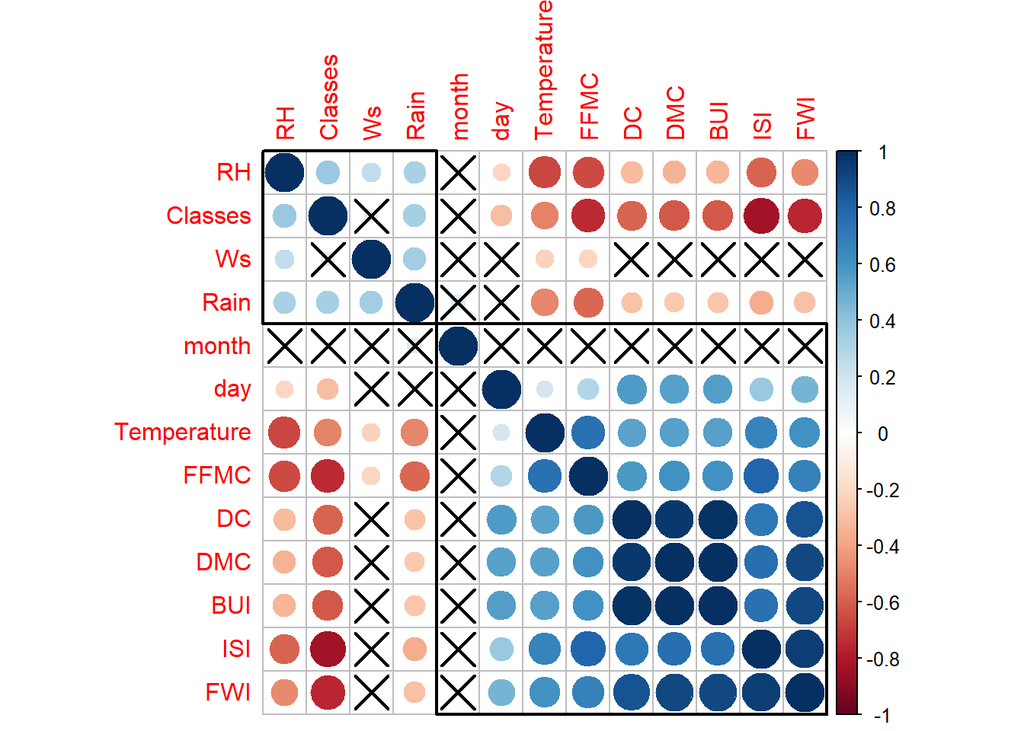

```r
corrplot(cor(tempRegion1Data),p.mat = test1$p, sig.level = 0.10, order = 'hclust', addrect = 2)
```

### Region 2

```r
tempRegion2Data$day=as.numeric(tempRegion2Data$day)
tempRegion2Data$month=as.numeric(tempRegion2Data$month)
tempRegion2Data$year=as.numeric(tempRegion2Data$year)
tempRegion2Data$Temperature=as.numeric(tempRegion2Data$Temperature)
tempRegion2Data$RH=as.numeric(tempRegion2Data$RH)
tempRegion2Data$Ws=as.numeric(tempRegion2Data$Ws)
tempRegion2Data$Classes=as.numeric(tempRegion2Data$Classes)
tempRegion2Data = subset(tempRegion2Data, select = -c(year) )

corr_region2_mat <- corr.test(tempRegion2Data)$p
test2 = cor.mtest(tempRegion2Data, conf.level = 0.95)

randomForestRegion2 <- randomForest(as.factor(Classes) ~., data=tempRegion2Data)
importance(randomForestRegion2)
```

```
##             MeanDecreaseGini
## day               0.19664874
## month             0.03715869
## Temperature       0.54398011
## RH                0.54025264
## Ws                0.10180627
## Rain              1.47856428
## FFMC             18.21613127
## DMC               2.47779414
## DC                3.51721123
## ISI              15.40479806
## BUI               3.43323703
## FWI               9.18435198
```

```r
cor(tempRegion2Data)
```

```
##                     day        month Temperature           RH          Ws
## day          1.00000000  0.000000000  0.02616760  0.008625210  0.03063310
## month        0.00000000  1.000000000 -0.08467577 -0.009430222 -0.07844745
## Temperature  0.02616760 -0.084675775  1.00000000 -0.598309253 -0.25820770
## RH           0.00862521 -0.009430222 -0.59830925  1.000000000  0.14143599
## Ws           0.03063310 -0.078447452 -0.25820770  0.141435994  1.00000000
## Rain        -0.14459831 -0.140057033 -0.12971778  0.149026700 -0.13974009
## FFMC         0.15502497  0.088331901  0.57312162 -0.645539941 -0.01940612
## DMC          0.46674357  0.136658912  0.38974756 -0.379056643  0.02876499
## DC           0.48779654  0.291330014  0.28450643 -0.265698471  0.01714009
## ISI          0.07710321  0.117241065  0.53824583 -0.692334771  0.13371286
## BUI          0.47976008  0.185088144  0.36775587 -0.360802029  0.02974004
## FWI          0.27627441  0.146933583  0.50059028 -0.604374430  0.10769549
## Classes     -0.09823876 -0.115857767 -0.50175721  0.444215136 -0.05345013
##                   Rain        FFMC         DMC          DC         ISI
## day         -0.1445983  0.15502497  0.46674357  0.48779654  0.07710321
## month       -0.1400570  0.08833190  0.13665891  0.29133001  0.11724107
## Temperature -0.1297178  0.57312162  0.38974756  0.28450643  0.53824583
## RH           0.1490267 -0.64553994 -0.37905664 -0.26569847 -0.69233477
## Ws          -0.1397401 -0.01940612  0.02876499  0.01714009  0.13371286
## Rain         1.0000000 -0.51049793 -0.34843121 -0.34482281 -0.41347668
## FFMC        -0.5104979  1.00000000  0.58129954  0.48065778  0.75336977
## DMC         -0.3484312  0.58129954  1.00000000  0.88212161  0.62790036
## DC          -0.3448228  0.48065778  0.88212161  1.00000000  0.46827473
## ISI         -0.4134767  0.75336977  0.62790036  0.46827473  1.00000000
## BUI         -0.3580605  0.57702479  0.98791655  0.92752783  0.60868316
## FWI         -0.4105641  0.71944177  0.85103280  0.71388377  0.91585175
## Classes      0.4752876 -0.79626562 -0.53371238 -0.45838866 -0.69738511
##                     BUI        FWI     Classes
## day          0.47976008  0.2762744 -0.09823876
## month        0.18508814  0.1469336 -0.11585777
## Temperature  0.36775587  0.5005903 -0.50175721
## RH          -0.36080203 -0.6043744  0.44421514
## Ws           0.02974004  0.1076955 -0.05345013
## Rain        -0.35806047 -0.4105641  0.47528758
## FFMC         0.57702479  0.7194418 -0.79626562
## DMC          0.98791655  0.8510328 -0.53371238
## DC           0.92752783  0.7138838 -0.45838866
## ISI          0.60868316  0.9158518 -0.69738511
## BUI          1.00000000  0.8432379 -0.54486310
## FWI          0.84323790  1.0000000 -0.68380089
## Classes     -0.54486310 -0.6838009  1.00000000
```

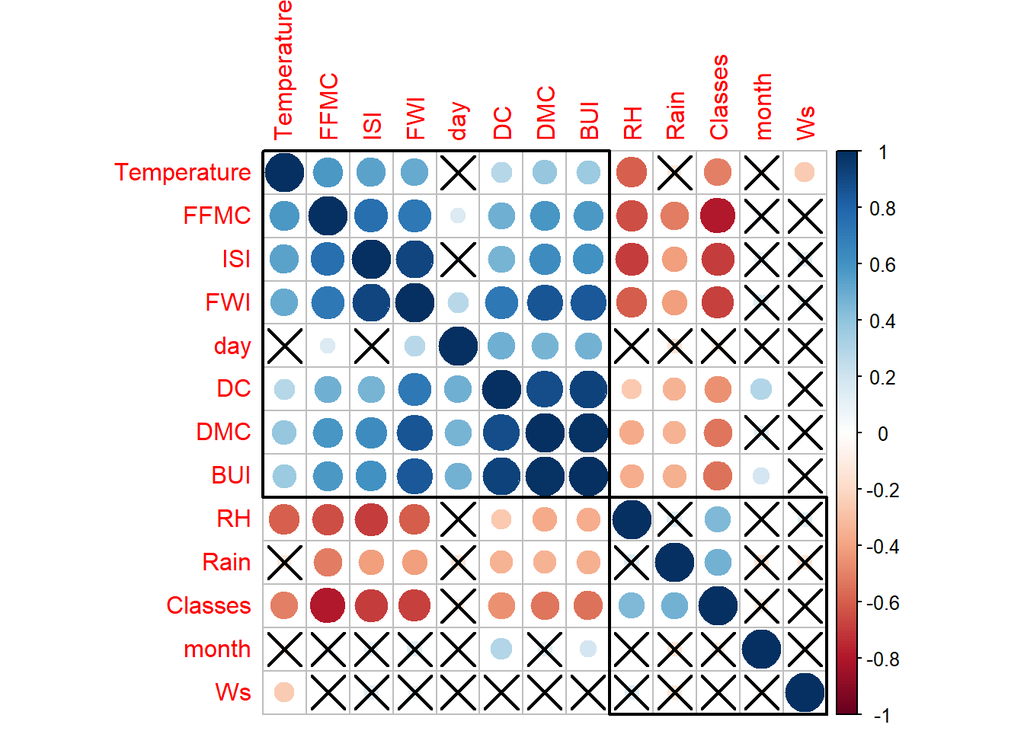

```r
corrplot(cor(tempRegion2Data),p.mat = test2$p, sig.level = 0.10, order = 'hclust', addrect = 2)
```

### Whole Region

```r
tempWholeRegionData$day=as.numeric(tempWholeRegionData$day)
tempWholeRegionData$month=as.numeric(tempWholeRegionData$month)
tempWholeRegionData$year=as.numeric(tempWholeRegionData$year)
tempWholeRegionData$Temperature=as.numeric(tempWholeRegionData$Temperature)
tempWholeRegionData$RH=as.numeric(tempWholeRegionData$RH)
tempWholeRegionData$Ws=as.numeric(tempWholeRegionData$Ws)
tempWholeRegionData$Classes=as.numeric(tempWholeRegionData$Classes)
tempWholeRegionData = subset(tempWholeRegionData, select = -c(year) )

corr_region3_mat <- corr.test(tempWholeRegionData)$p
test3 = cor.mtest(tempWholeRegionData, conf.level = 0.95)

randomForestWholeRegion <- randomForest(as.factor(Classes) ~., data=tempWholeRegionData)
importance(randomForestWholeRegion)
```

```
##             MeanDecreaseGini
## day                0.6571827
## month              0.2395342
## Temperature        1.7090108
## RH                 0.8897281
## Ws                 0.3513762
## Rain               4.6638364
## FFMC              32.7731384
## DMC                8.1835006
## DC                 7.9334131
## ISI               31.3047241
## BUI                7.7907498
## FWI               22.7343794
```

```r
cor(tempWholeRegionData)
```

```
##                     day       month Temperature          RH           Ws
## day          1.00000000  0.00000000  0.09577222 -0.07420934  0.047000864
## month        0.00000000  1.00000000 -0.05901677 -0.03788419 -0.041446731
## Temperature  0.09577222 -0.05901677  1.00000000 -0.65444339 -0.278132070
## RH          -0.07420934 -0.03788419 -0.65444339  1.00000000  0.236083817
## Ws           0.04700086 -0.04144673 -0.27813207  0.23608382  1.000000000
## Rain        -0.11226536  0.03532207 -0.32678564  0.22296812  0.170169492
## FFMC         0.22403207  0.01557668  0.67749078 -0.64565800 -0.163254963
## DMC          0.49157104  0.06817778  0.48310471 -0.40513286 -0.001245987
## DC           0.52792852  0.12767185  0.37049841 -0.22033018  0.076245365
## ISI          0.17930078  0.06354476  0.60597102 -0.68826794  0.012245022
## BUI          0.51722392  0.08556743  0.45641455 -0.34968491  0.030303036
## FWI          0.35023433  0.08173226  0.56683851 -0.58045749  0.033956886
## Classes     -0.20178443 -0.02233266 -0.51811858  0.43502267  0.066529122
##                    Rain        FFMC          DMC          DC         ISI
## day         -0.11226536  0.22403207  0.491571043  0.52792852  0.17930078
## month        0.03532207  0.01557668  0.068177780  0.12767185  0.06354476
## Temperature -0.32678564  0.67749078  0.483104707  0.37049841  0.60597102
## RH           0.22296812 -0.64565800 -0.405132858 -0.22033018 -0.68826794
## Ws           0.17016949 -0.16325496 -0.001245987  0.07624537  0.01224502
## Rain         1.00000000 -0.54404455 -0.288547607 -0.29680376 -0.34786155
## FFMC        -0.54404455  1.00000000  0.602390807  0.50391002  0.74075117
## DMC         -0.28854761  0.60239081  1.000000000  0.87535826  0.67835487
## DC          -0.29680376  0.50391002  0.875358264  1.00000000  0.50391871
## ISI         -0.34786155  0.74075117  0.678354870  0.50391871  1.00000000
## BUI         -0.29940881  0.59025083  0.982205615  0.94167182  0.64135102
## FWI         -0.32475513  0.69143046  0.875191422  0.73704096  0.92242179
## Classes      0.37944947 -0.77011406 -0.584188378 -0.50712245 -0.73614163
##                     BUI         FWI     Classes
## day          0.51722392  0.35023433 -0.20178443
## month        0.08556743  0.08173226 -0.02233266
## Temperature  0.45641455  0.56683851 -0.51811858
## RH          -0.34968491 -0.58045749  0.43502267
## Ws           0.03030304  0.03395689  0.06652912
## Rain        -0.29940881 -0.32475513  0.37944947
## FFMC         0.59025083  0.69143046 -0.77011406
## DMC          0.98220562  0.87519142 -0.58418838
## DC           0.94167182  0.73704096 -0.50712245
## ISI          0.64135102  0.92242179 -0.73614163
## BUI          1.00000000  0.85691155 -0.58454502
## FWI          0.85691155  1.00000000 -0.71940685
## Classes     -0.58454502 -0.71940685  1.00000000
```

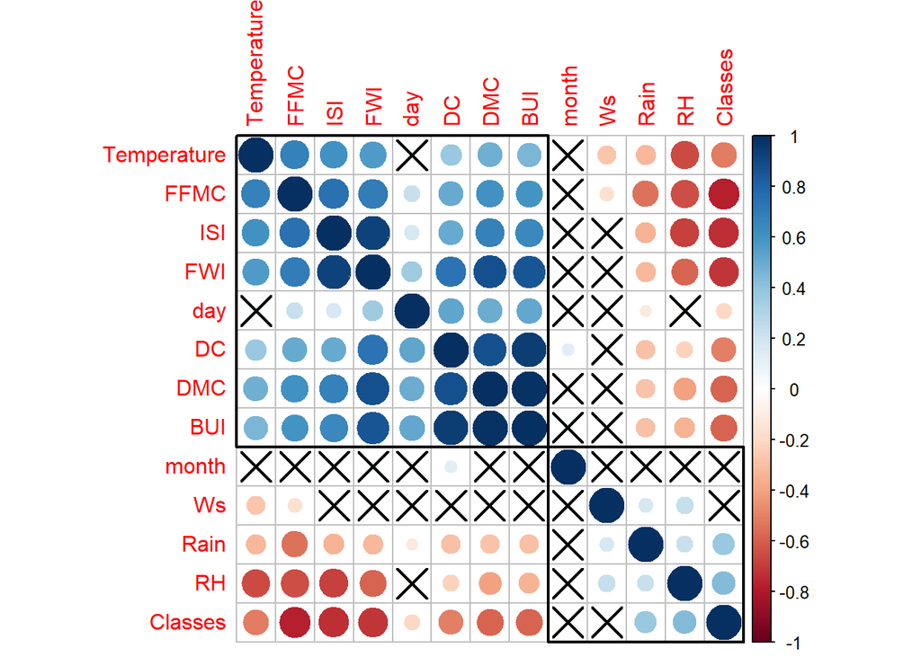

```r
corrplot(cor(tempWholeRegionData),p.mat = test3$p, sig.level = 0.10, order = 'hclust', addrect = 2)
```

Based on the above details, we expect that in addition to years, we can consider days, months, Ws and RH as not significant. We will take that into consideration while building our models.

## Logistic Regression

### Region 1

```r
suppressWarnings({
library(MLeval)
#remove the warning that we get considering it is a perfect separation

region1TrainData$Classes <- as.factor(trimws(region1TrainData$Classes))
region1TestData$Classes <- as.factor(trimws(region1TestData$Classes))
#remove the spaces to avoid dividing it into more than 2 categories

levels(region1TrainData$Classes) <- c('fire','not_fire')
levels(region1TestData$Classes) <- c('fire','not_fire')
#rename the labels to avoid getting errors from having a space in "not fire"

LRspecs <- trainControl(method="cv", number=10, savePredictions="all", classProbs=TRUE)
#save in LRspecs the specifications of the training method used

region1LRmodel <- train(Classes ~ ., data=region1TrainData, method="glm", family=binomial, trControl=LRspecs)
#create the model

variablesImportance = varImp(region1LRmodel)
print(variablesImportance)
#check the important variables

predictions = predict(region1LRmodel, newdata = region1TestData)
LRmatrixR1 = confusionMatrix(data=predictions,region1TestData$Classes)
LRmatrixR1
#check the predictions and create a confusion matrix to see its effectiveness

})
## glm variable importance
##
##             Overall
## FFMC        100.000
## Rain         67.519
## month        36.305
## FWI          35.536
## ISI          33.107
## Ws           26.059
## Temperature  13.978
## RH           13.709
## DMC           8.393
## DC            5.497
## day           1.485
## BUI           0.000
## Confusion Matrix and Statistics
##
##           Reference
## Prediction fire not_fire
##   fire       31        4
##   not_fire    2       24
##
##                Accuracy : 0.9016
##                  95% CI : (0.7981, 0.963)
##     No Information Rate : 0.541
##     P-Value [Acc > NIR] : 1.252e-09
##
##                   Kappa : 0.8009
##
##  Mcnemar's Test P-Value : 0.6831
##
##             Sensitivity : 0.9394
##             Specificity : 0.8571
##          Pos Pred Value : 0.8857
##          Neg Pred Value : 0.9231
##              Prevalence : 0.5410
##          Detection Rate : 0.5082
##    Detection Prevalence : 0.5738
##       Balanced Accuracy : 0.8983
##
##        'Positive' Class : fire
##
```

```r
LRmatrixR1$byClass
```

```
##          Sensitivity          Specificity       Pos Pred Value
##            0.9393939            0.8571429            0.8857143
##       Neg Pred Value            Precision               Recall
##            0.9230769            0.8857143            0.9393939
##                   F1           Prevalence       Detection Rate
##            0.9117647            0.5409836            0.5081967
## Detection Prevalence    Balanced Accuracy
##            0.5737705            0.8982684
```

```r
#show important metrics
```

Although the results are good with a 90% accuracy, 88.5% precision and 93.9% recall. We will reapply it without the features which were proved to be insignificant in our feature selection.

```r
suppressWarnings({
region1LRmodel2 <- train(Classes ~ Temperature+Rain+FFMC+DMC+DC+ISI+BUI+FWI, data=region1TrainData, method="glm", family=binomial, trControl=LRspecs)
#create the model

variablesImportance = varImp(region1LRmodel2)
print(variablesImportance)
#check the important variables

predictions = predict(region1LRmodel2, newdata = region1TestData)
LR2matrixR1 = confusionMatrix(data=predictions,region1TestData$Classes)
LR2matrixR1
#show confusion matrix
})
## glm variable importance
##
##             Overall
## ISI         100.000
## Rain         80.351
## DMC          70.364
## BUI          58.363
## Temperature  48.658
## DC           25.904
## FWI           9.055
## FFMC          0.000
## Confusion Matrix and Statistics
##
##           Reference
## Prediction fire not_fire
##   fire       32        1
##   not_fire    1       27
##
##                Accuracy : 0.9672
##                  95% CI : (0.8865, 0.996)
##     No Information Rate : 0.541
##     P-Value [Acc > NIR] : 7.261e-14
##
##                   Kappa : 0.934
##
##  Mcnemar's Test P-Value : 1
##
##             Sensitivity : 0.9697
##             Specificity : 0.9643
##          Pos Pred Value : 0.9697
##          Neg Pred Value : 0.9643
##              Prevalence : 0.5410
##          Detection Rate : 0.5246
##    Detection Prevalence : 0.5410
##       Balanced Accuracy : 0.9670
##
##        'Positive' Class : fire
##
```

```r
LR2matrixR1$byClass
```

```
##          Sensitivity          Specificity       Pos Pred Value
##            0.9696970            0.9642857            0.9696970
##       Neg Pred Value            Precision               Recall
##            0.9642857            0.9696970            0.9696970
##                   F1           Prevalence       Detection Rate
##            0.9696970            0.5409836            0.5245902
## Detection Prevalence    Balanced Accuracy
##            0.5409836            0.9669913
```

```r
#show important metric such as precision and recall
```

This time, we managed to get a 96.7% accuracy, 96.9% precision and 96.9% recall. This is a great improvement over our previous model.

### Region 2

```r
suppressWarnings({
#remove the warning that we get considering it is a perfect separation

region2TrainData$Classes <- as.factor(trimws(region2TrainData$Classes))
region2TestData$Classes <- as.factor(trimws(region2TestData$Classes))
#remove the spaces to avoid dividing it into more than 2 categories

levels(region2TrainData$Classes) <- c('fire','not_fire')
levels(region2TestData$Classes) <- c('fire','not_fire')
#rename the labels to avoid getting errors from having a space in "not fire"

region2LRmodel1 <- train(Classes ~ ., data=region2TrainData, method="glm", family=binomial, trControl=LRspecs)
#create the model

variablesImportance2 = varImp(region2LRmodel1)
print(variablesImportance2)
#check the important variables

predictions = predict(region2LRmodel1, newdata = region2TestData)
LR2matrixR1 = confusionMatrix(data=predictions,region2TestData$Classes)
#check the predictions and create a confusion matrix to see it's effectiveness
})
## glm variable importance
##
##              Overall
## FFMC        100.0000
## DMC          32.8164
## BUI          30.7829
## Rain         29.9861
## RH           29.1043
## day          24.0858
## month        21.1353
## DC           20.2190
## Temperature  13.0954
## ISI           8.2858
## Ws            0.4884
## FWI           0.0000
LR2matrixR1
## Confusion Matrix and Statistics
##
##           Reference
## Prediction fire not_fire
##   fire       41        1
##   not_fire    0       19
##
##                Accuracy : 0.9836
##                  95% CI : (0.912, 0.9996)
##     No Information Rate : 0.6721
##     P-Value [Acc > NIR] : 9.175e-10
##
##                   Kappa : 0.9623
##
##  Mcnemar's Test P-Value : 1
##
##             Sensitivity : 1.0000
##             Specificity : 0.9500
##          Pos Pred Value : 0.9762
##          Neg Pred Value : 1.0000
##              Prevalence : 0.6721
##          Detection Rate : 0.6721
##    Detection Prevalence : 0.6885
##       Balanced Accuracy : 0.9750
##
##        'Positive' Class : fire
##
```

```r
LR2matrixR1$byClass
```

```
##          Sensitivity          Specificity       Pos Pred Value
##            1.0000000            0.9500000            0.9761905
##       Neg Pred Value            Precision               Recall
##            1.0000000            0.9761905            1.0000000
##                   F1           Prevalence       Detection Rate
##            0.9879518            0.6721311            0.6721311
## Detection Prevalence    Balanced Accuracy
##            0.6885246            0.9750000
```

Although the resulting model is a good one with a 98.3% accuracy, 97.6% precision and 100% recall. We will reapply it without the features which were proved to be insignificant in our feature selection.

```r
suppressWarnings({
region2LRmodel2 <- train(Classes ~ Temperature+Rain+FFMC+DMC+DC+ISI+BUI+FWI, data=region2TrainData, method="glm", family=binomial, trControl=LRspecs)
#create the model

variablesImportance2 = varImp(region2LRmodel2)
print(variablesImportance2)
#check the important variables

predictions = predict(region2LRmodel2, newdata = region2TestData)
LR2matrixR2 = confusionMatrix(data=predictions,region2TestData$Classes)
#check the predictions and create a confusion matrix to see it's effectiveness

LR2matrixR2

})
## glm variable importance
##
##             Overall
## Rain        100.000
## ISI          34.108
## FWI          22.952
## DMC          21.934
## BUI          16.241
## FFMC         14.228
## DC            2.601
## Temperature   0.000
## Confusion Matrix and Statistics
##
##           Reference
## Prediction fire not_fire
##   fire       40        1
##   not_fire    1       19
##
##                Accuracy : 0.9672
##                  95% CI : (0.8865, 0.996)
##     No Information Rate : 0.6721
##     P-Value [Acc > NIR] : 1.391e-08
##
##                   Kappa : 0.9256
##
##  Mcnemar's Test P-Value : 1
##
##             Sensitivity : 0.9756
##             Specificity : 0.9500
##          Pos Pred Value : 0.9756
##          Neg Pred Value : 0.9500
##              Prevalence : 0.6721
##          Detection Rate : 0.6557
##    Detection Prevalence : 0.6721
##       Balanced Accuracy : 0.9628
##
##        'Positive' Class : fire
##
```

```r
LR2matrixR2$byClass
```

```
##          Sensitivity          Specificity       Pos Pred Value
##            0.9756098            0.9500000            0.9756098
##       Neg Pred Value            Precision               Recall
##            0.9500000            0.9756098            0.9756098
##                   F1           Prevalence       Detection Rate
##            0.9756098            0.6721311            0.6557377
## Detection Prevalence    Balanced Accuracy
##            0.6721311            0.9628049
```

We notice no improvement, but rather a slight decrease in recall and accuracy.